# The 14 GPCM Covariance Models

This notebook demonstrates the Phase 3 (v0.4 roadmap) addition: all 14 Celeux & Govaert (1995) Gaussian Parsimonious Clustering Models (GPCM) -- the same family `mclust` implements -- as `covariance_type` options on `GaussianMixture`, plus `select_model`'s mclust-style default of sweeping all 14 codes.

See the GPCM Covariance Models user guide for what each of the 14 codes means.

```python
import numpy as np
import torch
import matplotlib.pyplot as plt
import os

os.chdir('../')

from sklearn.datasets import load_iris
from tgmm import GaussianMixture, select_model
from tgmm.covariance.gpcm import GPCM_CODES
from tgmm.plotting import plot_gmm

random_state = 42
```

import numpy as np import torch import matplotlib.pyplot as plt import os os.chdir('../') from sklearn.datasets import load_iris from tgmm import GaussianMixture, select_model from tgmm.covariance.gpcm import GPCM_CODES from tgmm.plotting import plot_gmm random_state = 42

## Part 1: the classic iris petal measurements (2-D)

Petal length and width, the two features that most cleanly separate the 3 iris species -- small enough to sweep all 14 models x several `K` quickly, and 2-D enough to plot the winning model's component ellipses directly.

```python
iris = load_iris()
X_iris = torch.tensor(iris.data[:, [2, 3]], dtype=torch.float64)  # petal length, petal width

plt.figure(figsize=(5, 4))
plt.scatter(X_iris[:, 0], X_iris[:, 1], c=iris.target, cmap='viridis', s=15)
plt.xlabel('petal length (cm)')
plt.ylabel('petal width (cm)')
plt.title('Iris petal measurements (true species)')
plt.show()
```

iris = load_iris() X_iris = torch.tensor(iris.data[:, [2, 3]], dtype=torch.float64) # petal length, petal width plt.figure(figsize=(5, 4)) plt.scatter(X_iris[:, 0], X_iris[:, 1], c=iris.target, cmap='viridis', s=15) plt.xlabel('petal length (cm)') plt.ylabel('petal width (cm)') plt.title('Iris petal measurements (true species)') plt.show()

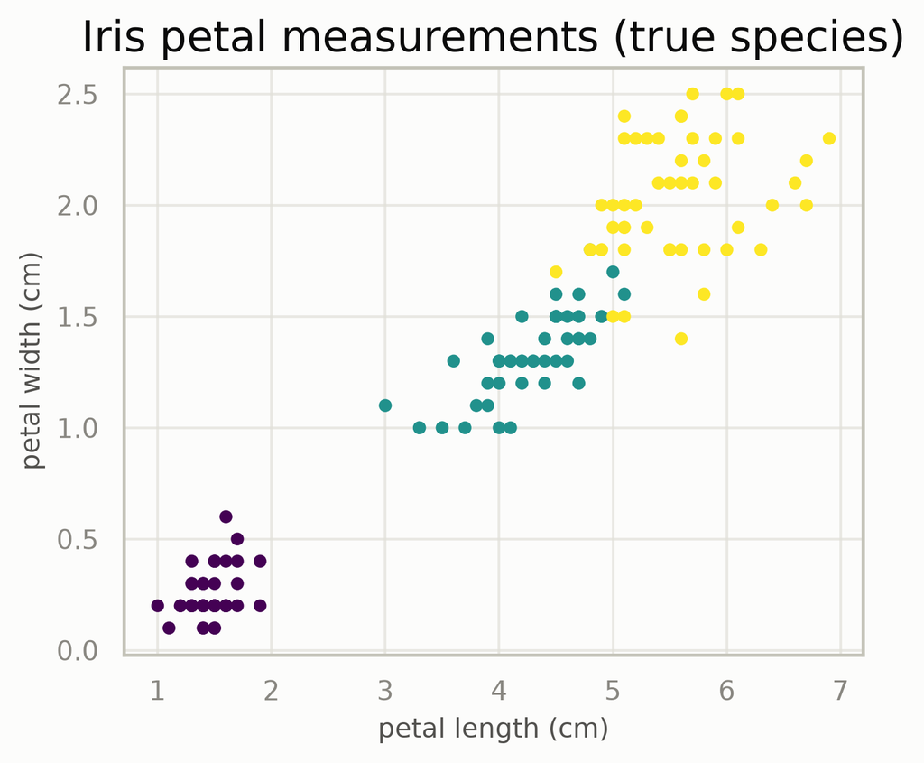

```python
result_iris = select_model(
    X_iris, n_components=range(1, 6), criterion='bic',
    random_state=random_state, n_init=1, max_iter=200,
)

df_iris = result_iris.to_dataframe().sort_values('bic')
df_iris.head(10)
```

result_iris = select_model( X_iris, n_components=range(1, 6), criterion='bic', random_state=random_state, n_init=1, max_iter=200, ) df_iris = result_iris.to_dataframe().sort_values('bic') df_iris.head(10)

|  | n_components | covariance_type | bic | aic | icl | log_likelihood | converged |
| --- | --- | --- | --- | --- | --- | --- | --- |
| 38 | 3 | VVE | 347.054572 | 301.895043 | 357.870257 | -0.906317 | True |
| 52 | 4 | VVE | 354.818447 | 294.605741 | 370.829914 | -0.848686 | True |
| 35 | 3 | VEE | 354.977590 | 315.839331 | 369.030985 | -0.966131 | True |
| 41 | 3 | VVV | 355.957404 | 304.776604 | 368.395953 | -0.902589 | True |
| 24 | 2 | VVE | 361.178482 | 331.072129 | 361.250534 | -1.036907 | True |
| 49 | 4 | VEE | 361.414820 | 310.234020 | 376.459484 | -0.920780 | True |
| 39 | 3 | VEV | 364.349955 | 319.190426 | 376.750136 | -0.963968 | True |
| 27 | 2 | VVV | 364.579644 | 331.462656 | 364.637312 | -1.031542 | True |
| 63 | 5 | VEE | 367.825650 | 304.602308 | 393.042373 | -0.875341 | True |
| 55 | 4 | VVV | 369.243180 | 299.998569 | 405.605136 | -0.846662 | True |

### BIC by model family and `K`

One line per covariance code, BIC against `K` -- lower is better.

```python
plt.figure(figsize=(9, 5))
for code_name in GPCM_CODES:
    sub = df_iris[df_iris['covariance_type'] == code_name].sort_values('n_components')
    sub = sub.dropna(subset=['bic'])
    if len(sub) == 0:
        continue
    plt.plot(sub['n_components'], sub['bic'], marker='o', markersize=3, label=code_name, alpha=0.7)
plt.xlabel('n_components (K)')
plt.ylabel('BIC (lower is better)')
plt.title('BIC across all 14 GPCM models, iris petal data')
plt.legend(ncol=2, fontsize=8)
plt.show()

best = result_iris.best_
print(f'Winning model: {best.covariance_type_} (K={best.n_components}), BIC={best.bic(X_iris):.2f}')
```

plt.figure(figsize=(9, 5)) for code_name in GPCM_CODES: sub = df_iris[df_iris['covariance_type'] == code_name].sort_values('n_components') sub = sub.dropna(subset=['bic']) if len(sub) == 0: continue plt.plot(sub['n_components'], sub['bic'], marker='o', markersize=3, label=code_name, alpha=0.7) plt.xlabel('n_components (K)') plt.ylabel('BIC (lower is better)') plt.title('BIC across all 14 GPCM models, iris petal data') plt.legend(ncol=2, fontsize=8) plt.show() best = result_iris.best_ print(f'Winning model: {best.covariance_type_} (K={best.n_components}), BIC={best.bic(X_iris):.2f}')

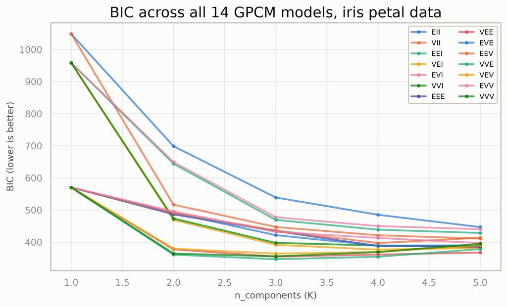

```
Winning model: VVE (K=3), BIC=347.05
```

### The winning model's component ellipses

```python
plt.figure(figsize=(6, 5))
plot_gmm(X_iris, gmm=best, true_labels=torch.tensor(iris.target), color_by_cluster=True)
plt.title(f'{best.covariance_type_} (K={best.n_components}) fit to iris petal measurements')
plt.show()
```

plt.figure(figsize=(6, 5)) plot_gmm(X_iris, gmm=best, true_labels=torch.tensor(iris.target), color_by_cluster=True) plt.title(f'{best.covariance_type_} (K={best.n_components}) fit to iris petal measurements') plt.show()

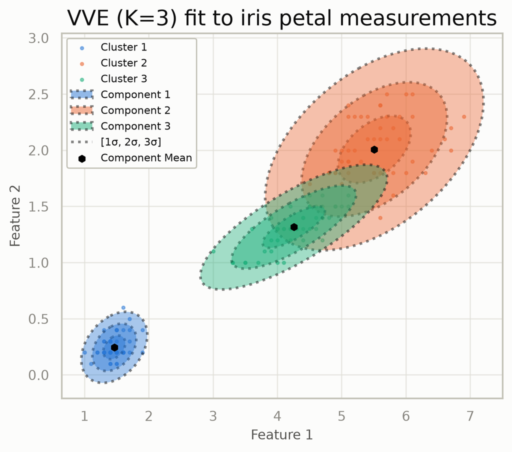

## Part 2: a 10-D latent-space-like dataset

Four clusters in 10 dimensions with deliberately varied covariance structure (different volumes, some axis-aligned, some correlated/elongated) -- the kind of thing a GPCM sweep is actually *for*: no single covariance type is obviously right, so the model-selection search has real work to do.

```python
def make_latent_cluster(n, d, seed, volume, elongation=None, rotate=False):
    gen = torch.Generator().manual_seed(seed)
    base = torch.randn(n, d, generator=gen, dtype=torch.float64)
    scale = torch.ones(d, dtype=torch.float64)
    if elongation is not None:
        scale[: len(elongation)] = torch.tensor(elongation, dtype=torch.float64)
    X = base * scale.sqrt() * volume
    if rotate:
        Q, _ = torch.linalg.qr(torch.randn(d, d, generator=gen, dtype=torch.float64))
        X = X @ Q.T
    return X

torch.manual_seed(random_state)
d = 10
centers = torch.randn(4, d, dtype=torch.float64) * 6
clusters = [
    make_latent_cluster(150, d, seed=1, volume=1.0) + centers[0],
    make_latent_cluster(150, d, seed=2, volume=1.8) + centers[1],
    make_latent_cluster(150, d, seed=3, volume=1.0, elongation=[4, 4, 1, 1, 1, 1, 1, 1, 1, 1]) + centers[2],
    make_latent_cluster(150, d, seed=4, volume=1.0, elongation=[4, 4, 1, 1, 1, 1, 1, 1, 1, 1], rotate=True) + centers[3],
]
X_latent = torch.cat(clusters, dim=0)
print(X_latent.shape)
```

def make_latent_cluster(n, d, seed, volume, elongation=None, rotate=False): gen = torch.Generator().manual_seed(seed) base = torch.randn(n, d, generator=gen, dtype=torch.float64) scale = torch.ones(d, dtype=torch.float64) if elongation is not None: scale[: len(elongation)] = torch.tensor(elongation, dtype=torch.float64) X = base * scale.sqrt() * volume if rotate: Q, _ = torch.linalg.qr(torch.randn(d, d, generator=gen, dtype=torch.float64)) X = X @ Q.T return X torch.manual_seed(random_state) d = 10 centers = torch.randn(4, d, dtype=torch.float64) * 6 clusters = [ make_latent_cluster(150, d, seed=1, volume=1.0) + centers[0], make_latent_cluster(150, d, seed=2, volume=1.8) + centers[1], make_latent_cluster(150, d, seed=3, volume=1.0, elongation=[4, 4, 1, 1, 1, 1, 1, 1, 1, 1]) + centers[2], make_latent_cluster(150, d, seed=4, volume=1.0, elongation=[4, 4, 1, 1, 1, 1, 1, 1, 1, 1], rotate=True) + centers[3], ] X_latent = torch.cat(clusters, dim=0) print(X_latent.shape)

```
torch.Size([600, 10])
```

```python
result_latent = select_model(
    X_latent, n_components=range(2, 6), criterion='bic',
    random_state=random_state, n_init=1, max_iter=100,
)

df_latent = result_latent.to_dataframe().sort_values('bic')
df_latent.head(10)
```

result_latent = select_model( X_latent, n_components=range(2, 6), criterion='bic', random_state=random_state, n_init=1, max_iter=100, ) df_latent = result_latent.to_dataframe().sort_values('bic') df_latent.head(10)

|  | n_components | covariance_type | bic | aic | icl | log_likelihood | converged |
| --- | --- | --- | --- | --- | --- | --- | --- |
| 33 | 4 | VVI | 21907.941776 | 21542.996615 | 21907.941776 | -17.814164 | True |
| 31 | 4 | VEI | 21916.855605 | 21670.627544 | 21916.855605 | -17.965523 | True |
| 45 | 5 | VEI | 21983.885007 | 21684.893791 | 22065.915103 | -17.957411 | True |
| 29 | 4 | VII | 21986.613174 | 21779.957480 | 21986.613174 | -18.071631 | True |
| 38 | 4 | VVE | 21990.115924 | 21427.308929 | 21990.115924 | -17.642757 | True |
| 47 | 5 | VVI | 22013.273801 | 21555.993117 | 22080.064980 | -17.789994 | True |
| 43 | 5 | VII | 22056.274831 | 21796.855982 | 22140.860137 | -18.065713 | True |
| 52 | 5 | VVE | 22083.877563 | 21428.735045 | 22120.824224 | -17.608946 | True |
| 35 | 4 | VEE | 22113.303741 | 21669.213846 | 22113.303741 | -17.889345 | True |
| 49 | 5 | VEE | 22180.738906 | 21683.885855 | 22254.017093 | -17.881572 | True |

### BIC vs ICL for the winning `K`

Both criteria, compared across models at the BIC-winning `K`.

```python
best_latent = result_latent.best_
winning_k = best_latent.n_components
print(f'Winning model: {best_latent.covariance_type_} (K={winning_k}), '
      f'BIC={best_latent.bic(X_latent):.2f}, ICL={best_latent.icl(X_latent):.2f}')

at_k = df_latent[df_latent['n_components'] == winning_k].dropna(subset=['bic', 'icl']).sort_values('bic')
at_k[['covariance_type', 'bic', 'icl', 'converged']].head(8)
```

best_latent = result_latent.best_ winning_k = best_latent.n_components print(f'Winning model: {best_latent.covariance_type_} (K={winning_k}), ' f'BIC={best_latent.bic(X_latent):.2f}, ICL={best_latent.icl(X_latent):.2f}') at_k = df_latent[df_latent['n_components'] == winning_k].dropna(subset=['bic', 'icl']).sort_values('bic') at_k[['covariance_type', 'bic', 'icl', 'converged']].head(8)

```
Winning model: VVI (K=4), BIC=21907.94, ICL=21907.94
```

|  | covariance_type | bic | icl | converged |
| --- | --- | --- | --- | --- |
| 33 | VVI | 21907.941776 | 21907.941776 | True |
| 31 | VEI | 21916.855605 | 21916.855605 | True |
| 29 | VII | 21986.613174 | 21986.613174 | True |
| 38 | VVE | 21990.115924 | 21990.115924 | True |
| 35 | VEE | 22113.303741 | 22113.303741 | True |
| 30 | EEI | 22442.458830 | 22442.458830 | True |
| 32 | EVI | 22446.458565 | 22446.458565 | True |
| 28 | EII | 22474.234238 | 22474.234238 | True |

## Takeaways

- `select_model`'s default sweep (all 14 GPCM codes) finds a sensible winner without having to guess a covariance structure up front -- `VVE`-ish results on the iris data (shared orientation, elongated per-species shapes) are a well-known finding for this dataset.
- On genuinely mixed-structure data (axis-aligned vs. correlated clusters, Part 2), no single covariance type dominates at every `K` -- exactly the situation the 14-model family is for.
- `volume_`/`shape_`/`orientation_` on the winning model expose *why* it won, not just that it did -- see the user guide for how to read them.